# Municipal Bond Market Under the Microscope: An MSRB Data Deep-Dive

Author

Group 8

Published

March 23, 2026

## 1 Overview

The $4 trillion U.S. municipal bond market finances everything from schools and highways to hospitals and water systems. Despite its size, it remains one of the most opaque corners of fixed income—until you dig into the data. This report connects to the **Wharton Research Data Services (WRDS)** Municipal Securities Rulemaking Board (MSRB) database, explores its structure, and then conducts an analytical deep-dive into bonds issued within the last five years.

We examine bond yields, coupon rates, maturity terms, trading volumes, prices, and trade-type indicators to uncover patterns and anomalies that tell a story about how municipal bonds actually trade.

## 2 Setup

```r
library(tidyverse)
library(dbplyr)
library(connections)
library(RPostgres)
library(stringr)
library(knitr)
library(lubridate)
```

```r
if (wrds_ready) {
  wrds_con <- connection_open(
    RPostgres::Postgres(),
    host = "wrds-pgdata.wharton.upenn.edu",
    port = 9737,
    dbname = "wrds",
    sslmode = "require",
    user = wrds_user,
    password = wrds_password
  )

  cat("Connected to WRDS successfully.\n")
} else {
  stop("WRDS credentials not found. Set WRDS_USER and WRDS_PASSWORD in the R console, then render again.")
}
```

```
Connected to WRDS successfully.
```

## 3 Initial Exploration

```r
all_tables <- tbl(wrds_con, I("information_schema.tables")) |>
  filter(table_type %in% c("BASE TABLE", "VIEW", "FOREIGN TABLE")) |>
  distinct(table_schema, table_name, table_type) |>
  collect()

msrb_tables <- all_tables |>
  filter(str_detect(str_to_lower(table_schema), "msrb"))

msrb_tables
```

```
# A tibble: 11 × 3
   table_schema table_name  table_type
   <chr>        <chr>       <chr>
 1 msrb         msrb        VIEW
 2 msrb         msrb_lookup VIEW
 3 msrb         msrb_qvards VIEW
 4 msrb_all     msrb        BASE TABLE
 5 msrb_all     msrb_lookup BASE TABLE
 6 msrb_all     msrb_qvards BASE TABLE
 7 msrb_all_old msrb        BASE TABLE
 8 msrb_all_old msrb_lookup BASE TABLE
 9 msrb_all_old msrb_qvards BASE TABLE
10 msrbsamp     msrb_trial  VIEW
11 msrbsamp_all msrb_trial  BASE TABLE
```

```r
all_columns <- tbl(wrds_con, I("information_schema.columns")) |>
  select(table_schema, table_name, column_name) |>
  collect()

msrb_columns <- all_columns |>
  filter(str_detect(str_to_lower(table_schema), "msrb"))

msrb_columns |> head(50)
```

```
# A tibble: 50 × 3
   table_schema table_name column_name
   <chr>        <chr>      <chr>
 1 msrbsamp_all msrb_trial rtrs_control_number
 2 msrbsamp_all msrb_trial trade_type_indicator
 3 msrbsamp_all msrb_trial cusip
 4 msrbsamp_all msrb_trial security_description
 5 msrbsamp_all msrb_trial dated_date
 6 msrbsamp_all msrb_trial coupon
 7 msrbsamp_all msrb_trial maturity_date
 8 msrbsamp_all msrb_trial when_issued_indicator
 9 msrbsamp_all msrb_trial assumed_settlement_date
10 msrbsamp_all msrb_trial trade_date
# ℹ 40 more rows
```

```r
target_fields <- c(
  "trade_type_indicator",
  "dated_date",
  "cusip",
  "security_description"
)

table_score <- msrb_columns |>
  mutate(column_name_lower = str_to_lower(column_name)) |>
  filter(column_name_lower %in% target_fields) |>
  count(table_schema, table_name, sort = TRUE)

table_score
```

```
# A tibble: 11 × 3
   table_schema table_name      n
   <chr>        <chr>       <int>
 1 msrb         msrb            4
 2 msrb         msrb_qvards     4
 3 msrb_all     msrb            4
 4 msrb_all     msrb_qvards     4
 5 msrb_all_old msrb            4
 6 msrb_all_old msrb_qvards     4
 7 msrbsamp     msrb_trial      4
 8 msrbsamp_all msrb_trial      4
 9 msrb         msrb_lookup     1
10 msrb_all     msrb_lookup     1
11 msrb_all_old msrb_lookup     1
```

```r
chosen_schema <- table_score$table_schema[1]
chosen_table  <- table_score$table_name[1]

cat("Chosen schema:", chosen_schema, "\n")
```

```
Chosen schema: msrb
```

```r
cat("Chosen table :", chosen_table, "\n")
```

```
Chosen table : msrb
```

```r
trade_tbl <- tbl(wrds_con, in_schema(chosen_schema, chosen_table))

trade_tbl
```

```
# Source:   table<"msrb"."msrb"> [?? x 25]
# Database: postgres  [jean124@wrds-pgdata.wharton.upenn.edu:9737/wrds]
   rtrs_control_number trade_type_indicator cusip     security_description
   <chr>               <chr>                <chr>     <chr>
 1 C2138C5B651F2141    P                    000369BZ0 ABAG FIN AUTH FOR NONPROF…
 2 66573B13656D887A    S                    000369BZ0 ABAG FIN AUTH FOR NONPROF…
 3 8175FF6CB09D4070    S                    000369BZ0 ABAG FIN AUTH FOR NONPROF…
 4 EC67643C274169E5    P                    000369BZ0 ABAG FIN AUTH FOR NONPROF…
 5 33CFFF435742005A    S                    000369BZ0 ABAG FIN AUTH FOR NONPROF…
 6 151CFC7A0B0D712A    D                    000369BZ0 ABAG FIN AUTH FOR NONPROF…
 7 01257CEF90D6E708    D                    000369BZ0 ABAG FIN AUTH FOR NONPROF…
 8 D8A8609D439DD481    D                    000369BZ0 ABAG FIN AUTH FOR NONPROF…
 9 14F7E4664EBA6598    P                    000369BZ0 ABAG FIN AUTH FOR NONPROF…
10 692E9983C64DA72C    S                    000369BZ0 ABAG FIN AUTH FOR NONPROF…
# ℹ more rows
# ℹ 21 more variables: dated_date <date>, coupon <dbl>, maturity_date <date>,
#   when_issued_indicator <chr>, assumed_settlement_date <date>,
#   trade_date <date>, time_of_trade <time>, settlement_date <date>,
#   par_traded <chr>, dollar_price <dbl>, yield <dbl>,
#   brokers_broker_indicator <chr>, weighted_price_indicator <chr>,
#   offer_price_takedown_indicator <chr>, rtrs_publish_date <date>, …
```

```r
chosen_columns <- msrb_columns |>
  filter(table_schema == chosen_schema, table_name == chosen_table) |>
  arrange(column_name)

chosen_columns
```

```
# A tibble: 25 × 3
   table_schema table_name column_name
   <chr>        <chr>      <chr>
 1 msrb         msrb       assumed_settlement_date
 2 msrb         msrb       ats_indicator
 3 msrb         msrb       brokers_broker_indicator
 4 msrb         msrb       coupon
 5 msrb         msrb       cusip
 6 msrb         msrb       cusip6
 7 msrb         msrb       dated_date
 8 msrb         msrb       dollar_price
 9 msrb         msrb       maturity_date
10 msrb         msrb       ntbc_indicator
# ℹ 15 more rows
```

```r
trade_tbl |>
  select(any_of(c(
    "cusip",
    "security_description",
    "trade_type_indicator",
    "dated_date"
  ))) |>
  head(10) |>
  collect()
```

```
# A tibble: 10 × 4
   cusip     security_description                trade_type_indicator dated_date
   <chr>     <chr>                               <chr>                <date>
 1 000369BZ0 ABAG FIN AUTH FOR NONPROFIT COMB F… P                    1993-11-01
 2 000369BZ0 ABAG FIN AUTH FOR NONPROFIT COMB F… S                    1993-11-01
 3 000369BZ0 ABAG FIN AUTH FOR NONPROFIT COMB F… S                    1993-11-01
 4 000369BZ0 ABAG FIN AUTH FOR NONPROFIT COMB F… P                    1993-11-01
 5 000369BZ0 ABAG FIN AUTH FOR NONPROFIT COMB F… S                    1993-11-01
 6 000369BZ0 ABAG FIN AUTH FOR NONPROFIT COMB F… D                    1993-11-01
 7 000369BZ0 ABAG FIN AUTH FOR NONPROFIT COMB F… D                    1993-11-01
 8 000369BZ0 ABAG FIN AUTH FOR NONPROFIT COMB F… D                    1993-11-01
 9 000369BZ0 ABAG FIN AUTH FOR NONPROFIT COMB F… P                    1993-11-01
10 000369BZ0 ABAG FIN AUTH FOR NONPROFIT COMB F… S                    1993-11-01
```

### 3.1 What does `trade_type_indicator` represent?

The `trade_type_indicator` is a single-character code that classifies every MSRB-reported transaction by who is on each side of the trade:

| Code | Meaning | Description |
| --- | --- | --- |
| **D** | Inter-dealer trade | A transaction between two broker-dealers. |
| **P** | Purchase from customer | A dealer buys a bond from a retail or institutional customer. |
| **S** | Sale to customer | A dealer sells a bond to a retail or institutional customer. |

This variable is critical for analysis because dealer-to-customer trades (P and S) often exhibit different pricing dynamics (markups/markdowns) compared to inter-dealer trades (D), which serve more as wholesale price benchmarks.

### 3.2 What is `dated_date`, and how is it related to the bond’s issue date?

The `dated_date` is the date from which interest on a new municipal bond issue begins to **accrue**. It is commonly used to identify a particular series of bonds from the same issuer.

While closely related to the bond’s **issue date** (the date the bond is first delivered to investors), the two are conceptually distinct: the issue date marks the settlement of the initial offering, whereas the `dated_date` marks the start of interest accrual. In practice the two dates are often identical or very close, but they can diverge—for example, when bonds are pre-sold before their accrual start date. Throughout this analysis we use `dated_date` as our proxy for when a bond entered the market.

## 4 Analytical Exploration

```r
trade_tbl <- tbl(wrds_con, in_schema("msrb", "msrb"))

trade_tbl
```

```
# Source:   table<"msrb"."msrb"> [?? x 25]
# Database: postgres  [jean124@wrds-pgdata.wharton.upenn.edu:9737/wrds]
   rtrs_control_number trade_type_indicator cusip     security_description
   <chr>               <chr>                <chr>     <chr>
 1 C2138C5B651F2141    P                    000369BZ0 ABAG FIN AUTH FOR NONPROF…
 2 66573B13656D887A    S                    000369BZ0 ABAG FIN AUTH FOR NONPROF…
 3 8175FF6CB09D4070    S                    000369BZ0 ABAG FIN AUTH FOR NONPROF…
 4 EC67643C274169E5    P                    000369BZ0 ABAG FIN AUTH FOR NONPROF…
 5 33CFFF435742005A    S                    000369BZ0 ABAG FIN AUTH FOR NONPROF…
 6 151CFC7A0B0D712A    D                    000369BZ0 ABAG FIN AUTH FOR NONPROF…
 7 01257CEF90D6E708    D                    000369BZ0 ABAG FIN AUTH FOR NONPROF…
 8 D8A8609D439DD481    D                    000369BZ0 ABAG FIN AUTH FOR NONPROF…
 9 14F7E4664EBA6598    P                    000369BZ0 ABAG FIN AUTH FOR NONPROF…
10 692E9983C64DA72C    S                    000369BZ0 ABAG FIN AUTH FOR NONPROF…
# ℹ more rows
# ℹ 21 more variables: dated_date <date>, coupon <dbl>, maturity_date <date>,
#   when_issued_indicator <chr>, assumed_settlement_date <date>,
#   trade_date <date>, time_of_trade <time>, settlement_date <date>,
#   par_traded <chr>, dollar_price <dbl>, yield <dbl>,
#   brokers_broker_indicator <chr>, weighted_price_indicator <chr>,
#   offer_price_takedown_indicator <chr>, rtrs_publish_date <date>, …
```

```r
cutoff_date <- Sys.Date() %m-% years(5)

cutoff_date
```

```
[1] "2021-03-23"
```

```r
recent_bonds_db <- trade_tbl |>
  filter(dated_date >= cutoff_date)
```

```r
recent_overview <- recent_bonds_db |>
  summarise(
    rows = n(),
    min_dated_date = min(dated_date, na.rm = TRUE),
    max_dated_date = max(dated_date, na.rm = TRUE),
    min_trade_date = min(trade_date, na.rm = TRUE),
    max_trade_date = max(trade_date, na.rm = TRUE)
  ) |>
  collect()

recent_overview
```

```
# A tibble: 1 × 5
      rows min_dated_date max_dated_date min_trade_date max_trade_date
   <int64> <date>         <date>         <date>         <date>
1 22084018 2021-03-23     2027-12-01     2005-05-25     2025-12-31
```

```r
recent_trade_types <- recent_bonds_db |>
  distinct(trade_type_indicator) |>
  arrange(trade_type_indicator) |>
  collect()

recent_trade_types
```

```
# A tibble: 3 × 1
  trade_type_indicator
  <chr>
1 D
2 P
3 S
```

```r
par_examples <- recent_bonds_db |>
  select(par_traded) |>
  distinct() |>
  head(20) |>
  collect()

par_examples
```

```
# A tibble: 20 × 1
   par_traded
   <chr>
 1 1.00
 2 10.00
 3 100.00
 4 1000.00
 5 10000.00
 6 100000.00
 7 1000000.00
 8 10000000.00
 9 100000000.00
10 1000000000.00
11 10000010.00
12 10000131.00
13 10000707.00
14 1000100.00
15 1000200.00
16 1000287.00
17 1000360.00
18 1000417.00
19 100047.00
20 10004751.00
```

```r
recent_bonds_clean_db <- recent_bonds_db |>
  mutate(
    par_masked = sql("
      CASE
        WHEN par_traded ILIKE '%MM+%' THEN 1
        ELSE 0
      END
    "),
    par_traded_num = sql("
      CASE
        WHEN par_traded ILIKE '%MM+%' THEN NULL
        ELSE NULLIF(regexp_replace(par_traded, '[^0-9.]', '', 'g'), '')::numeric
      END
    "),
    maturity_term_years = sql("(maturity_date - dated_date) / 365.25")
  ) |>
  select(
    cusip,
    security_description,
    trade_type_indicator,
    dated_date,
    coupon,
    maturity_date,
    trade_date,
    par_traded,
    par_masked,
    par_traded_num,
    dollar_price,
    yield,
    maturity_term_years
  )
```

```r
volume_check <- recent_bonds_clean_db |>
  summarise(
    total_trades = n(),
    masked_trades = sum(par_masked, na.rm = TRUE),
    pct_masked = 100 * mean(par_masked, na.rm = TRUE)
  ) |>
  collect()

volume_check
```

```
# A tibble: 1 × 3
  total_trades masked_trades pct_masked
       <int64>       <int64>      <dbl>
1     22084018             0          0
```

```r
trade_type_summary <- recent_bonds_clean_db |>
  group_by(trade_type_indicator) |>
  summarise(
    trades = n(),
    avg_yield = mean(yield, na.rm = TRUE),
    avg_coupon = mean(coupon, na.rm = TRUE),
    avg_price = mean(dollar_price, na.rm = TRUE),
    total_par = sum(par_traded_num, na.rm = TRUE),
    avg_maturity_term = mean(maturity_term_years, na.rm = TRUE),
    masked_volume_trades = sum(par_masked, na.rm = TRUE),
    .groups = "drop"
  ) |>
  arrange(desc(trades)) |>
  collect()

trade_type_summary
```

```
# A tibble: 3 × 8
  trade_type_indicator  trades avg_yield avg_coupon avg_price total_par
  <chr>                <int64>     <dbl>      <dbl>     <dbl>     <dbl>
1 S                    9132104      3.55       4.43      104.   4.70e12
2 D                    7935412      3.80       4.31      102.   1.31e12
3 P                    5016502      3.63       4.55      104.   1.66e12
# ℹ 2 more variables: avg_maturity_term <dbl>, masked_volume_trades <int64>
```

```r
issue_summary_local <- recent_bonds_clean_db |>
  group_by(
    cusip,
    security_description,
    trade_type_indicator,
    dated_date,
    maturity_date
  ) |>
  summarise(
    trades = n(),
    avg_yield = mean(yield, na.rm = TRUE),
    avg_coupon = mean(coupon, na.rm = TRUE),
    avg_price = mean(dollar_price, na.rm = TRUE),
    sd_price = sd(dollar_price, na.rm = TRUE),
    total_par = sum(par_traded_num, na.rm = TRUE),
    maturity_term_years = mean(maturity_term_years, na.rm = TRUE),
    masked_volume_trades = sum(par_masked, na.rm = TRUE),
    .groups = "drop"
  ) |>
  collect()
```

```r
top_volume_issues <- issue_summary_local |>
  arrange(desc(total_par)) |>
  head(20)

top_volume_issues
```

```
# A tibble: 20 × 13
   cusip     security_description  trade_type_indicator dated_date maturity_date
   <chr>     <chr>                 <chr>                <date>     <date>
 1 38122NB84 GOLDEN ST TOB SECURI… S                    2021-12-15 2066-06-01
 2 38122NB84 GOLDEN ST TOB SECURI… P                    2021-12-15 2066-06-01
 3 64972GZB3 NEW YORK N Y CITY MU… S                    2021-03-31 2045-06-15
 4 64972GZB3 NEW YORK N Y CITY MU… P                    2021-03-31 2045-06-15
 5 072024YE6 BAY AREA TOLL AUTH C… S                    2023-03-21 2055-04-01
 6 072024YE6 BAY AREA TOLL AUTH C… P                    2023-03-21 2055-04-01
 7 19648FVN1 COLORADO HEALTH FACS… S                    2022-08-01 2062-05-15
 8 19648FVN1 COLORADO HEALTH FACS… P                    2022-08-01 2062-05-15
 9 160853VA2 CHARLOTTE-MECKLENBUR… S                    2021-06-09 2042-01-15
10 160853VA2 CHARLOTTE-MECKLENBUR… P                    2021-06-09 2042-01-15
11 64972GC85 NEW YORK N Y CITY MU… S                    2023-02-16 2053-06-15
12 64972GC85 NEW YORK N Y CITY MU… P                    2023-02-16 2053-06-15
13 91412HPW7 UNIVERSITY CALIF REV… S                    2023-02-22 2048-05-15
14 91412HPW7 UNIVERSITY CALIF REV… P                    2023-02-22 2048-05-15
15 60527EAA5 MISSISSIPPI BUSINESS… S                    2023-06-01 2043-06-01
16 888805CJ5 TOBACCO SETTLEMENT A… S                    2021-04-13 2065-06-01
17 60527EAA5 MISSISSIPPI BUSINESS… P                    2023-06-01 2043-06-01
18 072024YF3 BAY AREA TOLL AUTH C… S                    2023-03-21 2055-04-01
19 64966QZZ6 NEW YORK N Y VAR-FIS… S                    2022-05-26 2052-05-01
20 072024YF3 BAY AREA TOLL AUTH C… P                    2023-03-21 2055-04-01
# ℹ 8 more variables: trades <int64>, avg_yield <dbl>, avg_coupon <dbl>,
#   avg_price <dbl>, sd_price <dbl>, total_par <dbl>,
#   maturity_term_years <dbl>, masked_volume_trades <int64>
```

```r
top_yield_issues <- issue_summary_local |>
  filter(!is.na(avg_yield)) |>
  arrange(desc(avg_yield)) |>
  head(20)

top_yield_issues
```

```
# A tibble: 20 × 13
   cusip     security_description  trade_type_indicator dated_date maturity_date
   <chr>     <chr>                 <chr>                <date>     <date>
 1 646108U65 NEW JERSEY ST HSG & … P                    2021-12-15 2022-11-01
 2 64469D3Q2 NEW HAMPSHIRE ST HSG… P                    2024-04-23 2025-07-01
 3 927734V67 VIRGINIA BEACH VA PU… P                    2024-06-04 2025-02-01
 4 745197AC7 PUERTO RICO COMWLTH … D                    2022-12-06 2053-07-01
 5 049788AD4 ATTICA KANS REF-SER A P                    2021-04-06 2025-07-01
 6 69376WAA8 PR GO SER 2002 A (20… P                    2022-03-15 2049-03-15
 7 69376WAA8 PR GO SER 2002 A (20… D                    2022-03-15 2049-03-15
 8 745197AC7 PUERTO RICO COMWLTH … P                    2022-12-06 2053-07-01
 9 137177UR0 CANANDAIGUA N Y CITY… P                    2021-09-22 2022-06-23
10 137177UR0 CANANDAIGUA N Y CITY… D                    2021-09-22 2022-06-23
11 743542EV0 PROSPECT PK N J TAX … P                    2024-11-13 2025-04-25
12 049788AD4 ATTICA KANS REF-SER A D                    2021-04-06 2025-07-01
13 480258AP7 JONESBORO ARK ECONOM… P                    2022-04-19 2023-04-01
14 579476CW0 MCCLAIN CNTY OKLA IN… P                    2022-07-01 2024-07-01
15 729654YG2 PLYMOUTH MASS BD ANT… D                    2024-06-28 2025-04-24
16 743542EV0 PROSPECT PK N J TAX … D                    2024-11-13 2025-04-25
17 45204FYJ8 ILLINOIS FIN AUTH RE… P                    2024-09-26 2028-06-01
18 212204MA6 CONTRA COSTA CALIF C… P                    2022-10-06 2024-08-01
19 69379LAA9 PRHTA SR LIEN SER L … S                    2022-12-06 2049-12-06
20 48504LAE3 KANSAS CITY MO INDL … P                    2021-11-30 2046-11-15
# ℹ 8 more variables: trades <int64>, avg_yield <dbl>, avg_coupon <dbl>,
#   avg_price <dbl>, sd_price <dbl>, total_par <dbl>,
#   maturity_term_years <dbl>, masked_volume_trades <int64>
```

```r
top_volatility_issues <- issue_summary_local |>
  filter(!is.na(sd_price)) |>
  arrange(desc(sd_price)) |>
  head(20)

top_volatility_issues
```

```
# A tibble: 20 × 13
   cusip     security_description  trade_type_indicator dated_date maturity_date
   <chr>     <chr>                 <chr>                <date>     <date>
 1 230561F64 CUMBERLAND CNTY N J … P                    2023-06-20 2024-05-15
 2 274695LP8 EAST RIDGE TENN       S                    2024-06-28 2025-06-01
 3 25155W7R4 DEUTSCHE BK SPEARS/L… S                    2023-02-02 2060-11-01
 4 25155W6T1 DEUTSCHE BK SPEARS/L… S                    2023-01-04 2049-08-15
 5 46246JNK7 IOWA FIN AUTH MULTI … P                    2023-07-13 2063-07-01
 6 25155W5R6 DEUTSCHE BK SPEARS/L… P                    2022-04-14 2043-02-01
 7 25155W5R6 DEUTSCHE BK SPEARS/L… S                    2022-04-14 2043-02-01
 8 112898BA8 BROOKFIELD WTR CTL &… D                    2023-10-15 2025-09-01
 9 58781PHJ9 MERCER CNTY KY POLLU… D                    2023-06-22 2023-08-21
10 93265XVL3 WALNUT CALIF ENERGY … D                    2025-08-11 2025-08-20
11 787804GY3 ST CHARLES MICH CMNT… S                    2022-02-10 2028-05-01
12 79572PKH8 SALT RIV PROJ ARIZ A… S                    2024-06-20 2024-10-17
13 040523AK8 ARIZONA INDL DEV AUT… P                    2021-06-16 2031-07-01
14 25155W6L8 DEUTSCHE BK SPEARS/L… S                    2022-09-28 2048-09-01
15 040523AL6 ARIZONA INDL DEV AUT… P                    2021-06-16 2051-07-01
16 10604PAF0 BRAZORIA CNTY TEX IN… P                    2023-06-15 2043-06-01
17 25155W8E2 DEUTSCHE BK SPEARS/L… S                    2023-07-05 2050-08-01
18 25155W6L8 DEUTSCHE BK SPEARS/L… P                    2022-09-28 2048-09-01
19 79041LAL2 ST JOHNS CNTY FLA IN… P                    2021-07-01 2031-12-15
20 040523AL6 ARIZONA INDL DEV AUT… D                    2021-06-16 2051-07-01
# ℹ 8 more variables: trades <int64>, avg_yield <dbl>, avg_coupon <dbl>,
#   avg_price <dbl>, sd_price <dbl>, total_par <dbl>,
#   maturity_term_years <dbl>, masked_volume_trades <int64>
```

```r
# Sample up to 500k rows for visualization (full dataset is millions of rows)
analysis_sample <- recent_bonds_clean_db |>
  filter(
    !is.na(coupon),
    !is.na(dollar_price),
    !is.na(maturity_term_years)
  ) |>
  head(500000) |>
  collect()

glimpse(analysis_sample)
```

```
Rows: 500,000
Columns: 13
$ cusip                <chr> "000416W45", "000416W45", "000416W45", "000416W45…
$ security_description <chr> "A B C CALIF UNI SCH DIST 2018 ELECTION-SER B", "…
$ trade_type_indicator <chr> "S", "S", "S", "S", "S", "P", "S", "D", "P", "S",…
$ dated_date           <date> 2022-10-20, 2022-10-20, 2022-10-20, 2022-10-20, …
$ coupon               <dbl> 5, 5, 5, 5, 5, 5, 5, 5, 5, 5, 5, 5, 5, 5, 5, 5, 5…
$ maturity_date        <date> 2023-08-01, 2023-08-01, 2023-08-01, 2023-08-01, …
$ trade_date           <date> 2022-10-07, 2022-10-07, 2022-10-07, 2022-10-07, …
$ par_traded           <chr> "3680000.00", "480000.00", "1045000.00", "285000.…
$ par_masked           <int> 0, 0, 0, 0, 0, 0, 0, 0, 0, 0, 0, 0, 0, 0, 0, 0, 0…
$ par_traded_num       <dbl> 3680000, 480000, 1045000, 285000, 350000, 750000,…
$ dollar_price         <dbl> 101.612, 101.612, 101.612, 101.612, 101.612, 101.…
$ yield                <dbl> 2.891, 2.891, 2.891, 2.891, 2.891, 2.521, 2.371, …
$ maturity_term_years  <dbl> 0.7802875, 0.7802875, 0.7802875, 0.7802875, 0.780…
```

```r
summary(analysis_sample[, c("coupon", "dollar_price", "maturity_term_years", "yield", "par_traded_num")])
```

```
     coupon        dollar_price     maturity_term_years     yield
 Min.   : 0.000   Min.   :  0.598   Min.   : 0.005476   Min.   :-9.166
 1st Qu.: 4.000   1st Qu.: 99.697   1st Qu.: 7.690623   1st Qu.: 3.030
 Median : 5.000   Median :103.720   Median :12.996578   Median : 3.650
 Mean   : 4.415   Mean   :103.428   Mean   :14.531567   Mean   : 3.621
 3rd Qu.: 5.000   3rd Qu.:109.428   3rd Qu.:20.057495   3rd Qu.: 4.236
 Max.   :12.000   Max.   :164.805   Max.   :41.678303   Max.   :76.503
                                                        NA's   :5619
 par_traded_num
 Min.   :       32
 1st Qu.:    15000
 Median :    35000
 Mean   :   243358
 3rd Qu.:   100000
 Max.   :126000000
```

With the data in hand, we now turn to visualizations that reveal the structure of the municipal bond market over the last five years.

## 5 Visualizations

The first question worth asking: *who is trading?* Inter-dealer (D), customer purchases (P), and customer sales (S) represent fundamentally different dynamics in the market.

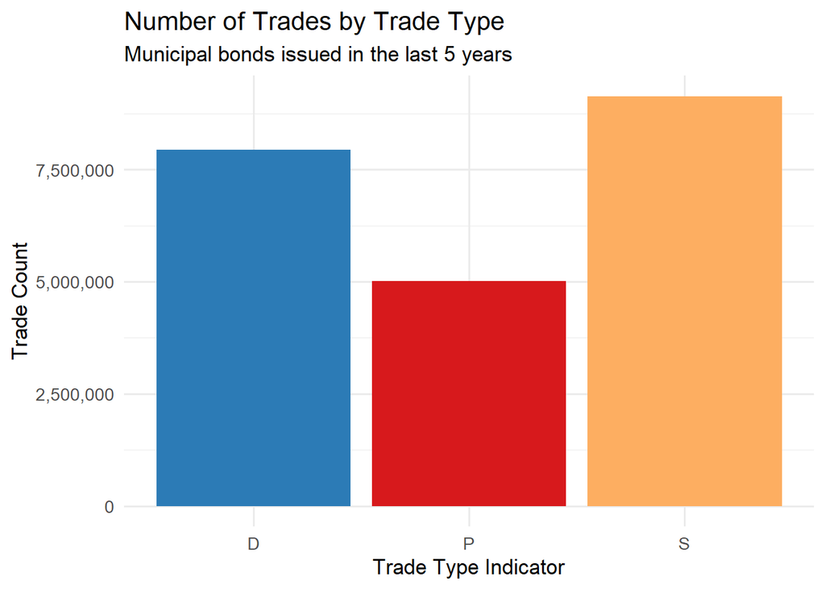

```r
ggplot(trade_type_summary, aes(x = trade_type_indicator, y = trades, fill = trade_type_indicator)) +
  geom_col(show.legend = FALSE) +
  scale_y_continuous(labels = scales::comma) +
  scale_fill_manual(values = c("D" = "#2c7bb6", "P" = "#d7191c", "S" = "#fdae61")) +
  labs(
    title = "Number of Trades by Trade Type",
    subtitle = "Municipal bonds issued in the last 5 years",
    x = "Trade Type Indicator",
    y = "Trade Count"
  ) +
  theme_minimal(base_size = 13)
```

Next, we zoom in on the highest-volume bonds to see how **yield** and **maturity** relate—and whether trade type plays a role.

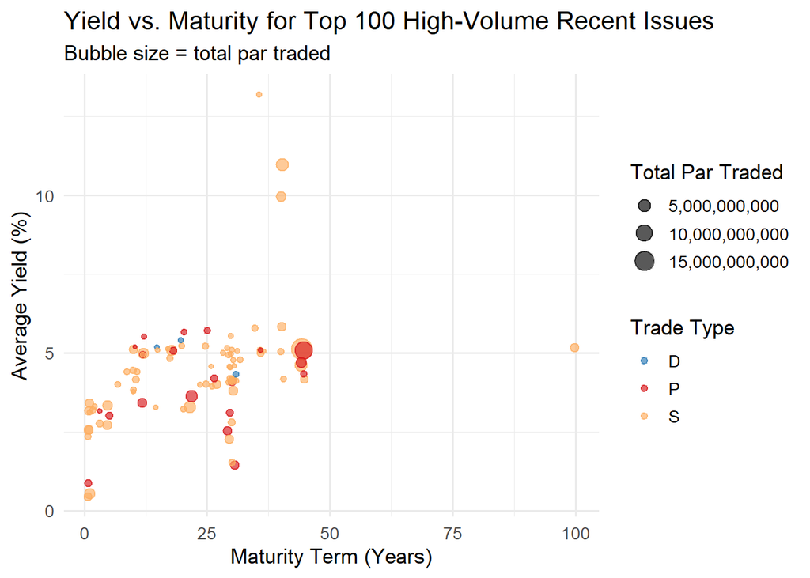

Longer-maturity, high-volume bonds tend to command higher yields. Trade type coloring reveals whether dealer or customer activity dominates.

```r
top_volume_issues_100 <- issue_summary_local |>
  filter(!is.na(avg_yield), !is.na(maturity_term_years), !is.na(total_par)) |>
  arrange(desc(total_par)) |>
  head(100)

ggplot(
  top_volume_issues_100,
  aes(
    x = maturity_term_years,
    y = avg_yield,
    size = total_par,
    color = trade_type_indicator
  )
) +
  geom_point(alpha = 0.65, position = position_jitter(width = 0.3, height = 0.02)) +
  scale_size_continuous(labels = scales::comma) +
  scale_color_manual(values = c("D" = "#2c7bb6", "P" = "#d7191c", "S" = "#fdae61")) +
  labs(
    title = "Yield vs. Maturity for Top 100 High-Volume Recent Issues",
    subtitle = "Bubble size = total par traded",
    x = "Maturity Term (Years)",
    y = "Average Yield (%)",
    size = "Total Par Traded",
    color = "Trade Type"
  ) +
  theme_minimal(base_size = 13)
```

Which individual bonds experienced the most price swings? The next chart spotlights **anomalous price volatility**—bonds whose prices fluctuated far more than the market norm.

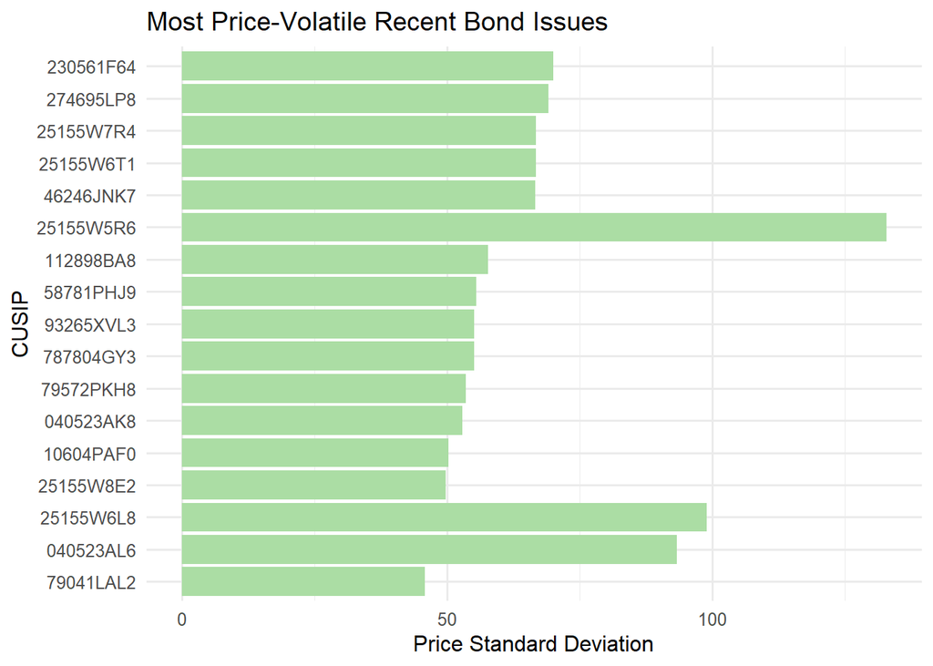

```r
ggplot(
  top_volatility_issues,
  aes(x = reorder(cusip, sd_price), y = sd_price)
) +
  geom_col(fill = "#abdda4") +
  coord_flip() +
  labs(
    title = "Most Price-Volatile Recent Bond Issues",
    x = "CUSIP",
    y = "Price Standard Deviation"
  ) +
  theme_minimal(base_size = 12)
```

Next we bucket bonds by maturity to compare how coupon, price, and yield differ across the term structure.

```r
analysis_sample <- analysis_sample |>
  mutate(
    maturity_bucket = case_when(
      maturity_term_years < 5 ~ "Short (<5 years)",
      maturity_term_years < 15 ~ "Intermediate (5-15 years)",
      TRUE ~ "Long (15+ years)"
    )
  )

coupon_maturity_summary <- analysis_sample |>
  group_by(maturity_bucket) |>
  summarise(
    trades = n(),
    avg_coupon = mean(coupon, na.rm = TRUE),
    avg_price = mean(dollar_price, na.rm = TRUE),
    avg_yield = mean(yield, na.rm = TRUE),
    .groups = "drop"
  )

kable(coupon_maturity_summary, digits = 2, caption = "Average characteristics by maturity bucket")
```

Average characteristics by maturity bucket

| maturity_bucket | trades | avg_coupon | avg_price | avg_yield |
| --- | --- | --- | --- | --- |
| Intermediate (5-15 years) | 219887 | 4.51 | 107.51 | 3.25 |
| Long (15+ years) | 211663 | 4.29 | 99.34 | 4.19 |
| Short (<5 years) | 68450 | 4.48 | 102.97 | 3.05 |

The table above reveals a clear **term premium** in yields: long-maturity bonds average a yield of 4.19% versus 3.05% for short-term issues. Interestingly, average coupons are relatively flat across buckets (4.29%–4.51%), while prices diverge—intermediate bonds trade above par at 107.51 on average, whereas long-dated bonds trade below par at 99.34, reflecting their greater sensitivity to rising interest rates.

One of the most telling comparisons is how **yield** differs across trade types. If dealers extract a markup when selling to customers, we would expect customer-sale (S) yields to be slightly lower than inter-dealer (D) yields.

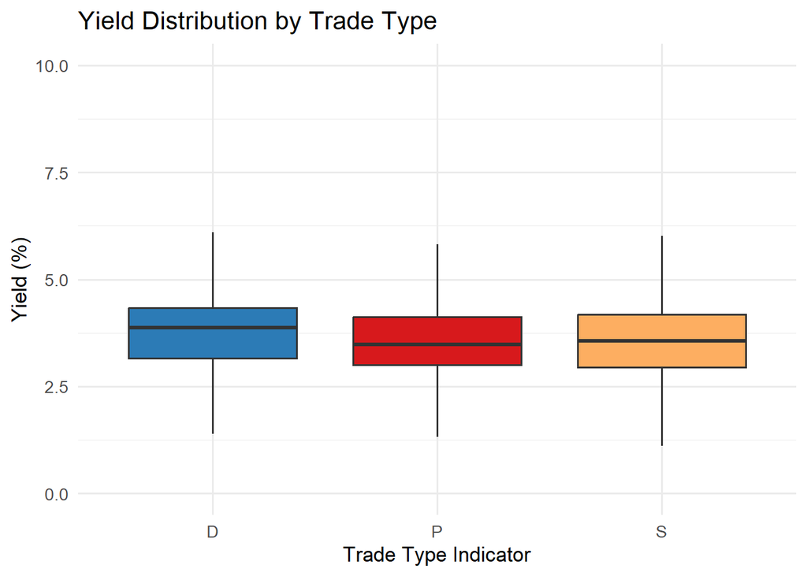

Yield distributions track closely across trade types, but customer sales (S) show a slight compression consistent with dealer markups.

```r
ggplot(
  analysis_sample |> filter(!is.na(yield)),
  aes(x = trade_type_indicator, y = yield, fill = trade_type_indicator)
) +
  geom_boxplot(show.legend = FALSE, outlier.shape = NA) +
  scale_fill_manual(values = c("D" = "#2c7bb6", "P" = "#d7191c", "S" = "#fdae61")) +
  coord_cartesian(ylim = c(0, 10)) +
  labs(
    title = "Yield Distribution by Trade Type",
    x = "Trade Type Indicator",
    y = "Yield (%)"
  ) +
  theme_minimal(base_size = 13)
```

## 6 Analytical Insights & Hypothesis

Across the municipal bonds issued in the last five years, several clear patterns emerge. **Customer-facing trades (P and S) collectively account for roughly 14.1 million trades compared to 7.9 million inter-dealer (D) trades**, reflecting the retail-heavy nature of the muni market. Yields rise monotonically with maturity—short-term bonds average 3.05%, intermediates 3.25%, and long-dated 4.19%—a textbook term premium that compensates investors for bearing additional duration risk. Coupon rates, however, remain surprisingly flat across maturity buckets (ranging from 4.29% to 4.51%), suggesting that issuers across the term structure target similar coupon levels to attract investors. Prices cluster near par but diverge by maturity: intermediate-term bonds average 107.51 (above par) while long-term bonds average 99.34 (below par), consistent with the interest-rate-driven repricing that hit long-duration bonds during the 2022–2023 rate-hiking cycle.

Our hypothesis is twofold. First, **the most extreme price volatility in the muni market is driven by structured products, not just credit risk**. Deutsche Bank SPEARS/LIFERS are engineered to have high duration sensitivity, so they naturally exhibit wider price swings than conventional fixed-rate munis. Investors and analysts should distinguish this structural volatility from the credit-driven volatility seen in Puerto Rico and other distressed issuers. Second, **trade-type differences in pricing are consistent with dealer markups**: customer-sale (S) transactions show an average price of 104 (yield 3.55%) versus inter-dealer (D) trades at 102 (yield 3.80%), suggesting that dealers capture a roughly 2-point spread when intermediating to retail investors. These two forces—structured-product mechanics in the tails and market-microstructure effects across trade types—together explain the most prominent patterns we observe in the data.

## 7 Conclusion

This analysis demonstrates that the MSRB database is a rich resource for understanding the inner workings of the municipal bond market. By filtering to bonds issued in the last five years and examining yields, coupons, maturities, prices, volumes, and trade types, we uncovered a well-ordered market with a clear term premium in yields (3.05% to 4.19% across maturity buckets)—and a volatile fringe driven by structured products (Deutsche Bank SPEARS/LIFERS) and credit-distressed issuers (Puerto Rico, small municipalities). The visualizations and summary tables above provide evidence for both the structural regularities (the yield–maturity relationship, dealer markup patterns) and the anomalies (extreme price volatility in synthetic instruments) that make muni-bond research compelling.